# R Notebook

This dataset came from chatn gpt. The method of this data is that we can know how much have each country waste plastic in ocean, in two diffrent graphs, and the other graph is about total plastic produced, and total Recycled plastic.

# Plastic Waste in Ocean by Country

```r
library(dplyr)
library(stringr)
library(tidyverse)
library(psych)
```

I importated the library first

```r
df$Country <- factor(df$Country)

df$Plastic <- factor(df$Main_Plastic_Type)
```

In this part, I wanted to convert a column of country names in a data frame.

```r
df <- data.frame(
  Country = 1:20,
  Name_of_Country = c("CountryA", "CountryB", "CountryC", "CountryD", "CountryE", "CountryF", "CountryG", "CountryH", "CountryI", "CountryJ", "CountryK", "CountryL", "CountryM", "CountryN", "CountryO", "CountryP", "CountryQ", "CountryR", "CountryS", "CountryT"),
  Plastic_in_Ocean = c(209837, 416717, 308365, 740539, 339962, 350442, 532849, 210744, 116122, 1003791, 513854, 208546, 62853, 332889, 885390, 337829, 659724, 330153, 154423, 138220)
  )
```

In this part, I have made the country names to the Alphabets, because the numbers were not the real, and for each one, I put the plastic waste in ocean with numbers.

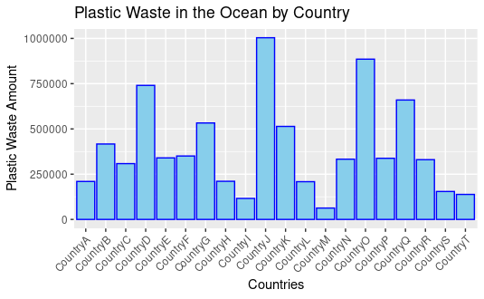

```r
ggplot(df, aes(x = Name_of_Country, y = Plastic_in_Ocean)) +
  geom_bar(stat = "identity", fill = "skyblue", color = "blue") +
  labs(title = "Plastic Waste in the Ocean by Country",
       x = "Countries",
       y = "Plastic Waste Amount") +
  theme(axis.text.x = element_text(angle = 45, hjust = 1))
```

This part is the part that making a graph of Plastic waste amount vs. Countries. I used the geom_bar for my graph, and used color of skyblue for inside, and for the outline, I used color of blue. On the last part, I used the element text, and tell R that angle will be 45, and hjust is 1.From my own graph, I discovered, that has highest plastic waste in the ocean has high population, but the lowest country that wasted plastic, they have like average population, but they have the lowest amount that they have waste plastic into the ocean.

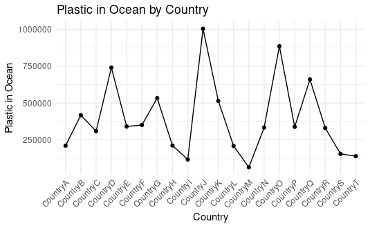

```r
library(ggplot2)

ggplot(df, aes(x = Name_of_Country, y = Plastic_in_Ocean, group = 1)) +
  geom_line() +
  geom_point() +
  labs(title = "Plastic in Ocean by Country",
       x = "Country",
       y = "Plastic in Ocean") +
  theme_minimal() +
  theme(axis.text.x = element_text(angle = 45, hjust = 1))
```

In this part, I wanted to make it clear that how is plastic in ocean between countries are different, and from that I notice that each country has different amount of plastic, and the line graph shows that.

```r
library(tidyverse)

model <- lm(Produced ~ Recycled, data = trash)

summary(model)
```

```
Call:
lm(formula = Produced ~ Recycled, data = trash)

Residuals:
     Min       1Q   Median       3Q      Max
-5461924 -4886452  -223117  4368893  6715110

Coefficients:
             Estimate Std. Error t value Pr(>|t|)
(Intercept) 6.585e+06  1.738e+06   3.788  0.00135 **
Recycled    1.882e+00  3.218e-01   5.849 1.54e-05 ***
---
Signif. codes:  0 ‘***’ 0.001 ‘**’ 0.01 ‘*’ 0.05 ‘.’ 0.1 ‘ ’ 1

Residual standard error: 4795000 on 18 degrees of freedom
Multiple R-squared:  0.6552,    Adjusted R-squared:  0.6361
F-statistic: 34.21 on 1 and 18 DF,  p-value: 1.538e-05
```

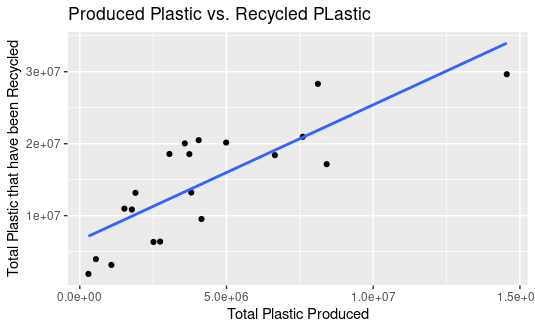

```r
ggplot(trash, aes(x = Recycled, y = Produced)) +
  geom_point() +
  geom_smooth(method = "lm", se = FALSE) +
  labs(title = "Produced Plastic vs. Recycled PLastic",
       x = "Total Plastic Produced",
       y = "Total Plastic that have been Recycled")
```

The black dots are the countries, and the line that is going through, is the line that represents the middle.The method of making this graph is that I wanted to know how much have the country produced the plastic, and how much have they recycled, and for my prediction, when plastic produce increases, the total plastic that recycled will be Increase too. Also I saw that not that much country have produced plastic, but have a high rate of recycling plastic.